# Exercise 3.1.1c (C3-P1)

- Show All Code
- Hide All Code

MATH411

Author

Nathan Lunceford

## Question

**Create a Python function that takes as input three points (six scalars, three pairs, or perhaps a 6-element numpy array–choose a method that makes sense to you) and uses the matplotlib package to create a figure window and then render a triangle with small open circles at each of the points and straight lines between each pair of circles. Include code to save your figure to a .png or .jpg file. Validate your function with the points (1, 2), (2, 1), and (2, 3).**

**Create function and figure**

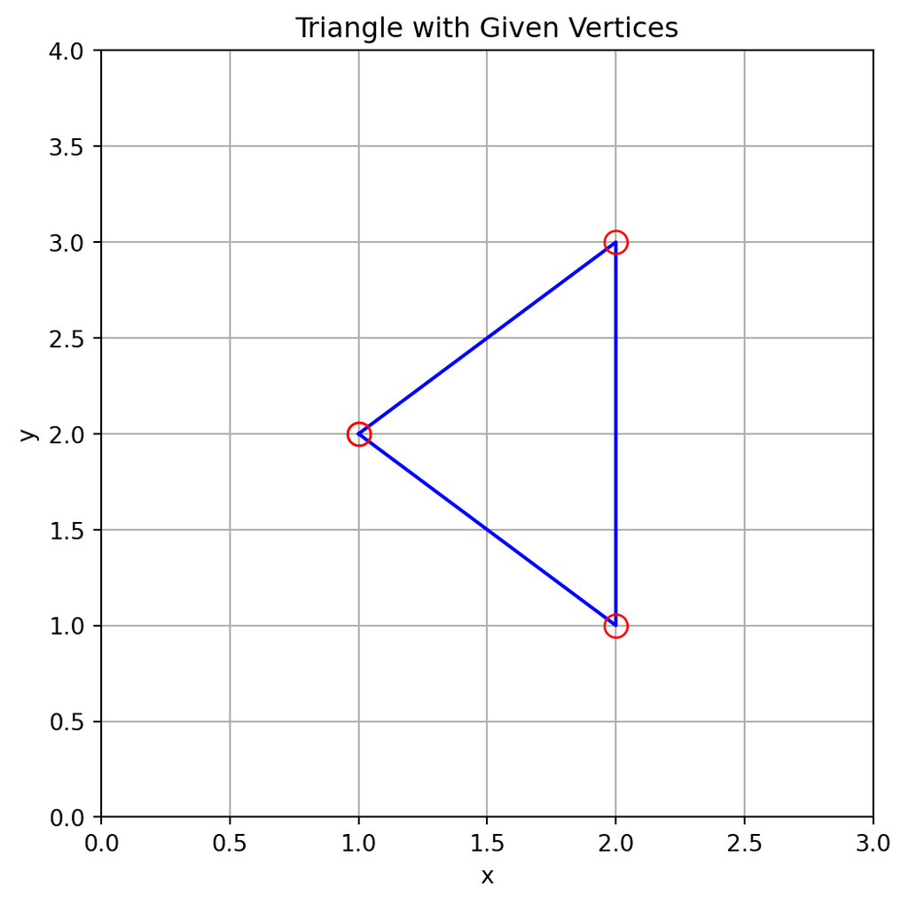

```python
# Define the function
def plot_triangle(points, save_path='triangle_plot.png'):
    """
    Takes an input of three points (a list of 3 tuples or a 3x2 numpy array)
    and plots a triangle with small open circles at each of the points.
    The triangle is rendered with lines connecting each point.

    Parameters:
    points (list of tuples or numpy array): Points representing the vertices of the triangle.
    save_path (str): File path to save the plotted figure.
    """

    # Ensure points is a numpy array
    points = np.array(points)

    # Check if the input is in the correct shape (3x2)
    if points.shape != (3, 2):
        raise ValueError("Input should be a list of 3 points, each as a pair of (x, y) coordinates.")

    # Extract the x and y coordinates
    x_coords = points[:, 0]
    y_coords = points[:, 1]

    # Close the triangle by repeating the first point at the end
    x_closed = np.append(x_coords, x_coords[0])
    y_closed = np.append(y_coords, y_coords[0])

    # Create the plot
    plt.figure(figsize=(6, 6))

    # Plot the triangle with open circles at each vertex
    plt.plot(x_closed, y_closed, 'b-', marker='o', markerfacecolor='none',
             markeredgecolor='r', markersize=10, label='Triangle')

    # Set labels and title
    plt.title("Triangle with Given Vertices")
    plt.xlabel("x")
    plt.ylabel("y")

    # Set axis limits for better visualization
    plt.xlim(min(x_closed) - 1, max(x_closed) + 1)
    plt.ylim(min(y_closed) - 1, max(y_closed) + 1)

    # Add grid for better visualization
    plt.grid(True)


    # Save the figure
    plt.savefig(save_path, dpi=300)

    # Show the plot
   #  plt.show()

# Test the function with the points (1, 2), (2, 1), and (2, 3)
test_points = [(1, 2), (2, 1), (2, 3)]
plot_triangle(test_points, save_path='triangle_plot.png')
```